# Percepción y justificación de desigualdad salariales/personales(status) ELSOC 2016-2017

Juan Carlos Castillo, 27 Marzo 2018

## 1. Directory, encoding & libraries

```r
knitr::opts_chunk$set(echo = TRUE, cache = TRUE)
knitr::opts_knit$set(root.dir = "/media/ntfs/Dropbox/proyectos y papers compartidos/Meritocracy and preferences/ELSOC2018meritocracia")
```

```r
Sys.setlocale("LC_ALL", 'en_US.UTF-8') # encoding
```

```
## [1] "LC_CTYPE=en_US.UTF-8;LC_NUMERIC=C;LC_TIME=en_US.UTF-8;LC_COLLATE=en_US.UTF-8;LC_MONETARY=en_US.UTF-8;LC_MESSAGES=en_US.UTF-8;LC_PAPER=es_CL.UTF-8;LC_NAME=C;LC_ADDRESS=C;LC_TELEPHONE=C;LC_MEASUREMENT=es_CL.UTF-8;LC_IDENTIFICATION=C"
```

```r
pacman::p_load(dplyr,  # data management
                 haven,   # read external data (ej: read_stata)
                 tidyverse,
                 tidyr,
                 corrplot,
                 ggplot2,
                 Hmisc, # rcorr
                 descr,
                 stargazer,
               sjPlot)
```

## 2. Data objects

```r
  elsocw1 <- read_stata("data/COESW1_Stata14_V3.dta")
  elsocw2 <- read_stata("data/Base_Lineal_COES2_corregida.dta")
```

## 3. Limpieza y merge variables de percepcion y justificación de desigualdad de salarios

(En ELSOC W1) - d3_a: percibido gerente - d3_b: percibido obrero - d4_a: justo gerente - d4_b: justo obrero

```r
  names(elsocw1)
  names(elsocw2)
```

- cambian las variable labels en W2, terminan en _esp)

Subsets para cada año

```r
  salarw1=elsocw1 %>% select(id,d3_a,d3_b,d4_a,d4_b)
  salarw2=elsocw2 %>% select(idencuesta,d3_a_esp,d3_b_esp,d4_a_esp,d4_b_esp)

  stargazer(as.data.frame(salarw1[2:5]), type = "html",digits=0, median = TRUE,
              mean.sd = FALSE)
```

| Statistic | N | Min | Median | Max |
| --- | --- | --- | --- | --- |
| d3_a | 2,984 | 0 | 10,000,000 | 100,000,000,000,000,000,000 |
| d3_b | 2,984 | 0 | 250,000 | 100,000,000,000,000,000,000 |
| d4_a | 2,984 | 0 | 5,000,000 | 100,000,000,000,000,000,000 |
| d4_b | 2,984 | 0 | 500,000 | 1,000,000,000,000,000,000,000 |

```r
  stargazer(as.data.frame(salarw2[2:5]), type = "html",digits=0, median = TRUE,
              mean.sd = FALSE)
```

| Statistic | N | Min | Median | Max |
| --- | --- | --- | --- | --- |
| d3_a_esp | 2,521 | 0 | 6,500,000 | 900,000,000 |
| d3_b_esp | 2,521 | 0 | 270,000 | 5,000,000 |
| d4_a_esp | 2,521 | 0 | 3,000,000 | 600,000,000 |
| d4_b_esp | 2,521 | 0 | 500,000 | 480,000,000 |

Rename sustantivo y homologado para merge

```r
  salarw1 <- rename(salarw1,
                    perge=d3_a,
                    perob=d3_b,
                    jusge=d4_a,
                    jusob=d4_b)

  salarw2 <- rename(salarw2,
                    id=idencuesta,
                    perge=d3_a_esp,
                    perob=d3_b_esp,
                    jusge=d4_a_esp,
                    jusob=d4_b_esp)
```

Add wave variable

```r
  salarw1$year=2016
  salarw2$year=2017
  salarw1$wave=1
  salarw2$wave=1 # para luego filtrar por casos con ambas olas
  names(salarw1)
```

```
## [1] "id"    "perge" "perob" "jusge" "jusob" "year"  "wave"
```

```r
  names(salarw2)
```

```
## [1] "id"    "perge" "perob" "jusge" "jusob" "year"  "wave"
```

Append datasets long (para limpieza unificada)

```r
  elsocsal=rbind(salarw1,salarw2)
  dim(elsocsal)
```

```
## [1] 5505    7
```

```r
  elsocsal %>% summarise_all(funs(sum(is.na(.))))
```

```
## # A tibble: 1 x 7
##      id perge perob jusge jusob  year  wave
##   <int> <int> <int> <int> <int> <int> <int>
## 1     0     0     0     0     0     0     0
```

Descriptivos

```r
plot
```

```
## function (x, y, ...)
## UseMethod("plot")
## <bytecode: 0x2899820>
## <environment: namespace:graphics>
```

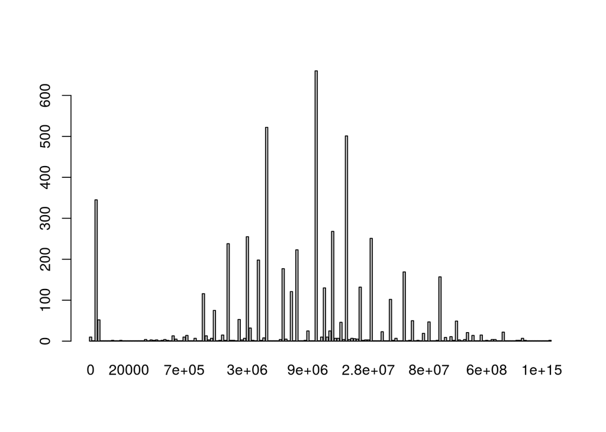

```
## El gerente de una gran empresa nacional?
##           Frequency   Percent
## 0                10   0.18165
## 2                 1   0.01817
## 88              345   6.26703
## 99               52   0.94460
## 208               1   0.01817
## 556               1   0.01817
## 568               1   0.01817
## 889               1   0.01817
## 999               2   0.03633
## 5828              1   0.01817
## 6582              1   0.01817
## 10000             2   0.03633
## 12000             1   0.01817
## 15088             1   0.01817
## 20000             1   0.01817
## 35568             1   0.01817
## 35652             1   0.01817
## 38383             1   0.01817
## 65863             1   0.01817
## 88888             1   0.01817
## 1e+05             4   0.07266
## 120000            1   0.01817
## 150000            3   0.05450
## 180000            2   0.03633
## 2e+05             3   0.05450
## 240000            1   0.01817
## 250000            2   0.03633
## 3e+05             4   0.07266
## 380000            2   0.03633
## 4e+05             1   0.01817
## 5e+05            13   0.23615
## 6e+05             5   0.09083
## 650000            1   0.01817
## 680000            1   0.01817
## 7e+05            10   0.18165
## 8e+05            14   0.25431
## 850000            1   0.01817
## 860000            1   0.01817
```

[output cut: 116 more lines]

```
## 2.5e+09           1   0.01817
## 3e+09             2   0.03633
## 4e+09             2   0.03633
## 5e+09             7   0.12716
## 6e+09             2   0.03633
## 7e+09             1   0.01817
## 9e+09             1   0.01817
## 1.5e+10           1   0.01817
## 2e+10             1   0.01817
## 2e+11             1   0.01817
## 1e+15             1   0.01817
## 1e+18             1   0.01817
## 1e+19             1   0.01817
## 1e+20             2   0.03633
## Total          5505 100.00000
```

```r
  freq(elsocsal$perge)
```

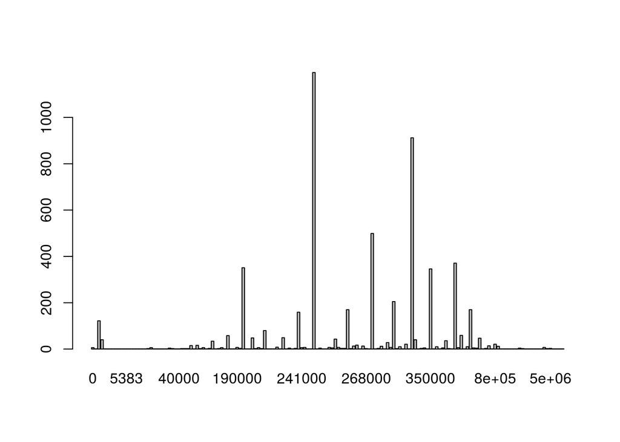

```
## Un obrero no calificado de una fabrica?
##         Frequency   Percent
## 0               6   0.10899
## 66              1   0.01817
## 88            122   2.21617
## 99             40   0.72661
## 300             1   0.01817
## 358             1   0.01817
## 400             1   0.01817
## 555             1   0.01817
## 595             1   0.01817
## 683             1   0.01817
## 2500            1   0.01817
## 5383            1   0.01817
## 5999            1   0.01817
```

[output cut: 142 more lines]

```r
  freq(elsocsal$perob)
```

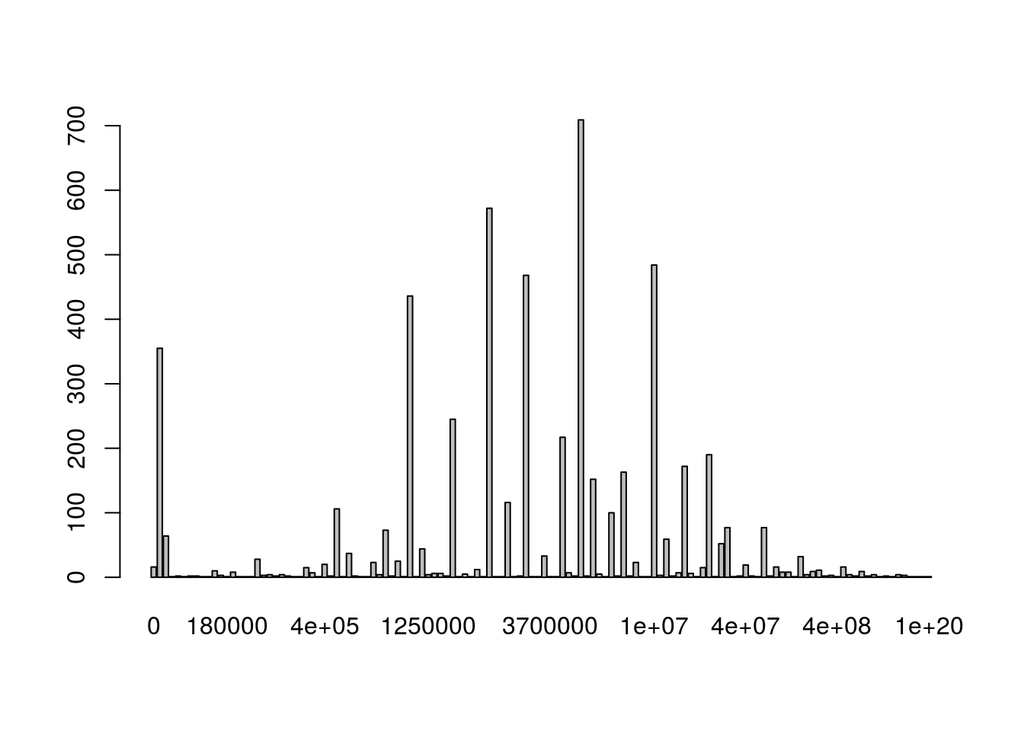

```
## El gerente de una gran empresa nacional?
##                 Frequency   Percent
## 0                      16   0.29064
## 88                    355   6.44868
## 99                     64   1.16258
## 888                     1   0.01817
## 999                     2   0.03633
## 10000                   1   0.01817
## 50000                   2   0.03633
## 80000                   2   0.03633
## 88888                   1   0.01817
## 90000                   1   0.01817
## 1e+05                  10   0.18165
## 150000                  3   0.05450
## 180000                  1   0.01817
## 2e+05                   8   0.14532
## 210000                  1   0.01817
## 241000                  1   0.01817
## 245000                  1   0.01817
## 250000                 28   0.50863
## 257000                  3   0.05450
## 260000                  4   0.07266
## 266000                  2   0.03633
## 270000                  4   0.07266
## 280000                  2   0.03633
## 282000                  1   0.01817
## 288000                  1   0.01817
## 3e+05                  15   0.27248
## 350000                  7   0.12716
## 380000                  1   0.01817
## 4e+05                  20   0.36331
## 450000                  2   0.03633
## 5e+05                 106   1.92552
## 550000                  1   0.01817
## 6e+05                  37   0.67212
## 650000                  2   0.03633
## 670000                  1   0.01817
## 680000                  1   0.01817
## 7e+05                  23   0.41780
## 750000                  4   0.07266
```

[output cut: 76 more lines]

```
## 6e+08                   4   0.07266
## 7e+08                   2   0.03633
## 1e+09                   9   0.16349
## 2e+09                   2   0.03633
## 3e+09                   4   0.07266
## 4e+09                   1   0.01817
## 5e+09                   2   0.03633
## 6e+09                   1   0.01817
## 7e+09                   4   0.07266
## 8e+09                   3   0.05450
## 999999999999999         1   0.01817
## 1e+15                   1   0.01817
## 1e+17                   1   0.01817
## 1e+20                   1   0.01817
## Total                5505 100.00000
```

```r
  freq(elsocsal$jusge)
```

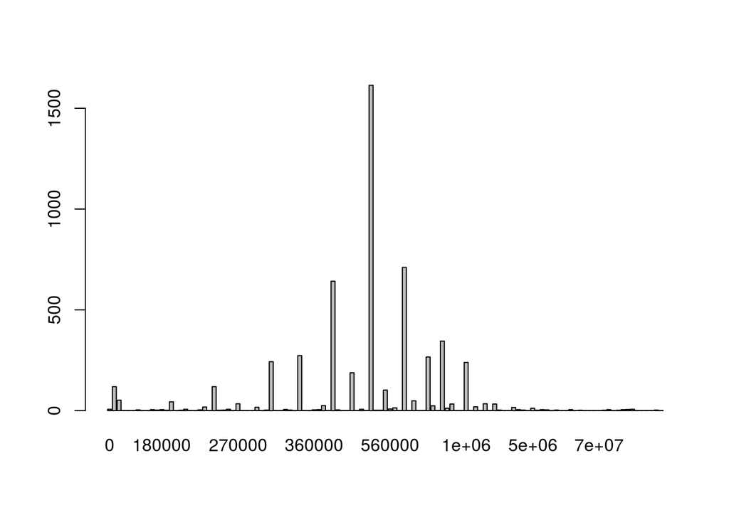

```
## Un obrero no calificado de una fabrica?
##          Frequency   Percent
## 0                7   0.12716
## 88             119   2.16167
## 99              52   0.94460
## 20000            1   0.01817
## 25000            1   0.01817
## 40000            1   0.01817
## 50000            4   0.07266
## 60000            1   0.01817
## 90000            1   0.01817
## 1e+05            5   0.09083
## 150000           3   0.05450
## 180000           5   0.09083
## 190000           2   0.03633
## 2e+05           44   0.79927
## 210000           1   0.01817
## 212000           2   0.03633
## 220000           7   0.12716
## 224000           1   0.01817
## 225000           1   0.01817
## 230000           4   0.07266
## 240000          18   0.32698
## 245000           1   0.01817
## 250000         119   2.16167
## 256000           2   0.03633
## 257000           3   0.05450
## 260000           7   0.12716
## 267000           1   0.01817
## 270000          34   0.61762
## 272000           1   0.01817
## 275000           1   0.01817
## 275500           1   0.01817
## 280000          17   0.30881
## 285000           1   0.01817
## 290000           3   0.05450
## 3e+05          243   4.41417
## 300008           1   0.01817
## 310000           1   0.01817
## 320000           6   0.10899
```

[output cut: 65 more lines]

```
## 7e+07            1   0.01817
## 1e+08            2   0.03633
## 2.5e+08          5   0.09083
## 2.65e+08         1   0.01817
## 2.85e+08         2   0.03633
## 3e+08            5   0.09083
## 3.2e+08          6   0.10899
## 3.5e+08          7   0.12716
## 3.6e+08          1   0.01817
## 3.8e+08          1   0.01817
## 4e+08            1   0.01817
## 4.5e+08          1   0.01817
## 4.8e+08          3   0.05450
## 1e+21            1   0.01817
## Total         5505 100.00000
```

```r
  freq(elsocsal$jusob)
```

- Sacar NAs, valores de menos de 50.000 y más de mil millones

```r
  elsocsal[2:5][elsocsal[2:5] ==88888] <- NA #missing encuesta
  elsocsal[2:5][elsocsal[2:5] <50000] <- NA
  elsocsal[2:5][elsocsal[2:5] >1000000000] <- NA
  elsocsal %>% group_by(year) %>%   summarise_all(funs(sum(is.na(.))))
```

```
## # A tibble: 2 x 7
##    year    id perge perob jusge jusob  wave
##   <dbl> <int> <int> <int> <int> <int> <int>
## 1  2016     0   169    60   170    43     0
## 2  2017     0   283   145   291   139     0
```

- Se puede observar que hay muchos más valores extremos en 2017 que eb 2016
- Pasar a Wide

```r
    elsocsalw= elsocsal %>%
      gather(variable, value, -(c(id,year))) %>%
      unite(temp, variable, year) %>% # puede ser year primero y queda al principio de la variable
      spread(temp,value)
  names(elsocsalw)
```

```
##  [1] "id"         "jusge_2016" "jusge_2017" "jusob_2016" "jusob_2017"
##  [6] "perge_2016" "perge_2017" "perob_2016" "perob_2017" "wave_2016"
## [11] "wave_2017"
```

```r
  dim(elsocsalw)
```

```
## [1] 2985   11
```

```r
  elsocsalw %>% summarise_all(funs(sum(!is.na(.))))
```

```
## # A tibble: 1 x 11
##      id jusge_2016 jusge_2017 jusob_2016 jusob_2017 perge_2016 perge_2017
##   <int>      <int>      <int>      <int>      <int>      <int>      <int>
## 1  2985       2814       2230       2941       2382       2815       2238
## # ... with 4 more variables: perob_2016 <int>, perob_2017 <int>,
## #   wave_2016 <int>, wave_2017 <int>
```

```r
    names(elsocsalw)
```

```
##  [1] "id"         "jusge_2016" "jusge_2017" "jusob_2016" "jusob_2017"
##  [6] "perge_2016" "perge_2017" "perob_2016" "perob_2017" "wave_2016"
## [11] "wave_2017"
```

```r
    summary(elsocsalw)
```

```
##        id              jusge_2016          jusge_2017
##  Min.   :  1101011   Min.   :5.000e+04   Min.   :    50000
##  1st Qu.:  5402052   1st Qu.:2.000e+06   1st Qu.:  1500000
##  Median :  8108141   Median :5.000e+06   Median :  3000000
##  Mean   :  8910432   Mean   :1.619e+07   Mean   :  8690722
##  3rd Qu.: 13111013   3rd Qu.:1.000e+07   3rd Qu.:  6000000
##  Max.   :131230214   Max.   :1.000e+09   Max.   :600000000
##                      NA's   :171         NA's   :755
##    jusob_2016          jusob_2017        perge_2016
##  Min.   :    50000   Min.   :5.0e+04   Min.   :6.586e+04
##  1st Qu.:   400000   1st Qu.:4.5e+05   1st Qu.:5.000e+06
##  Median :   500000   Median :5.0e+05   Median :1.000e+07
##  Mean   :   746396   Mean   :5.2e+06   Mean   :3.694e+07
##  3rd Qu.:   600000   3rd Qu.:6.5e+05   3rd Qu.:2.500e+07
##  Max.   :250000000   Max.   :4.8e+08   Max.   :1.000e+09
##  NA's   :44          NA's   :603       NA's   :170
##    perge_2017          perob_2016         perob_2017        wave_2016
##  Min.   :   100000   Min.   :   50000   Min.   :  80000   Min.   :1
##  1st Qu.:  4000000   1st Qu.:  250000   1st Qu.: 250000   1st Qu.:1
##  Median :  8000000   Median :  250000   Median : 272000   Median :1
##  Mean   : 21116032   Mean   :  323712   Mean   : 315497   Mean   :1
##  3rd Qu.: 20000000   3rd Qu.:  300000   3rd Qu.: 350000   3rd Qu.:1
##  Max.   :900000000   Max.   :35000000   Max.   :5000000   Max.   :1
##  NA's   :747         NA's   :61         NA's   :609       NA's   :1
##    wave_2017
##  Min.   :1
##  1st Qu.:1
##  Median :1
##  Mean   :1
##  3rd Qu.:1
##  Max.   :1
##  NA's   :464
```

- Datos casos ambas olas (w=waves)

```r
dim(elsocsalw)
```

```
## [1] 2985   11
```

```r
elsocsalwk = elsocsalw %>% filter(wave_2017==1)
dim(elsocsalwk)
```

```
## [1] 2521   11
```

## Descriptivos

Tablas

```r
  stargazer(as.data.frame(elsocsal[2:5]),
            type = 'html', digits=0, median = TRUE,
            mean.sd = FALSE, min.max = FALSE, title = "Medianas salarios percibido y justo agregados (2 olas" )
```

**Medianas salarios percibido y justo agregados (2 olas**

| Statistic | N | Median |
| --- | --- | --- |
| perge | 5,053 | 10,000,000 |
| perob | 5,300 | 270,000 |
| jusge | 5,044 | 4,000,000 |
| jusob | 5,323 | 500,000 |

```r
  stargazer(as.data.frame(elsocsalwk[2:9]),
            type = 'html', digits=0, median = TRUE,
            mean.sd = FALSE, min.max = FALSE, title = "Medianas de salarios por año")
```

**Medianas de salarios por año**

| Statistic | N | Median |
| --- | --- | --- |
| jusge_2016 | 2,374 | 5,000,000 |
| jusge_2017 | 2,230 | 3,000,000 |
| jusob_2016 | 2,487 | 500,000 |
| jusob_2017 | 2,382 | 500,000 |
| perge_2016 | 2,384 | 10,000,000 |
| perge_2017 | 2,238 | 8,000,000 |
| perob_2016 | 2,477 | 252,000 |
| perob_2017 | 2,376 | 272,000 |

Correlaciones

```r
   # Correlaciones obrero/gerente percibido/justo por año

  sjt.corr(elsocsalwk[2:9], triangle = "lower",na.deletion = c("pairwise"))
```

|  | jusge_2016 | jusge_2017 | jusob_2016 | jusob_2017 | perge_2016 | perge_2017 | perob_2016 | perob_2017 |
| --- | --- | --- | --- | --- | --- | --- | --- | --- |
| jusge_2016 |  |  |  |  |  |  |  |  |
| jusge_2017 | 0.008 |  |  |  |  |  |  |  |
| jusob_2016 | 0.081*** | -0.006 |  |  |  |  |  |  |
| jusob_2017 | -0.022 | -0.011 | -0.005 |  |  |  |  |  |
| perge_2016 | 0.361*** | 0.001 | 0.010 | -0.036 |  |  |  |  |
| perge_2017 | 0.034 | 0.444*** | -0.006 | -0.022 | 0.065** |  |  |  |
| perob_2016 | -0.013 | -0.007 | 0.016 | 0.038 | 0.086*** | 0.013 |  |  |
| perob_2017 | -0.016 | 0.001 | 0.004 | 0.020 | -0.005 | 0.122*** | 0.018 |  |
| Computed correlation used pearson-method with pairwise-deletion. |  |  |  |  |  |  |  |  |

```r
    cormat1=cor(elsocsalwk[2:9], use ="na.or.complete", method = "pearson")
    cormat1
```

```
##              jusge_2016   jusge_2017   jusob_2016  jusob_2017   perge_2016
## jusge_2016  1.000000000  0.018519953  0.112366077 -0.02365502  0.391591402
## jusge_2017  0.018519953  1.000000000 -0.006015650 -0.01164864  0.004410771
## jusob_2016  0.112366077 -0.006015650  1.000000000 -0.00519612  0.011930636
## jusob_2017 -0.023655022 -0.011648642 -0.005196120  1.00000000 -0.035571114
## perge_2016  0.391591402  0.004410771  0.011930636 -0.03557111  1.000000000
## perge_2017  0.046714206  0.455735664 -0.005530758 -0.02342253  0.081757733
## perob_2016 -0.009340651 -0.005915543  0.009340032  0.03603335  0.107682298
## perob_2017 -0.007704242 -0.001464122  0.005320390  0.02022260 -0.011120529
##              perge_2017   perob_2016   perob_2017
## jusge_2016  0.046714206 -0.009340651 -0.007704242
## jusge_2017  0.455735664 -0.005915543 -0.001464122
## jusob_2016 -0.005530758  0.009340032  0.005320390
## jusob_2017 -0.023422531  0.036033349  0.020222597
## perge_2016  0.081757733  0.107682298 -0.011120529
## perge_2017  1.000000000  0.013012366  0.133514884
## perob_2016  0.013012366  1.000000000  0.019699216
## perob_2017  0.133514884  0.019699216  1.000000000
```

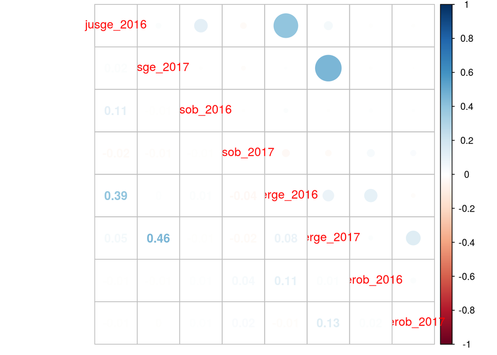

```r
    corrplot.mixed(cormat1)
```

… Aquí hay un problema, ver por ejemplo matriz de correlaciones de otro estudio panel 2 olas del FONDECYT “Justicia distributiva y participación ciudadana” (2013-2015, PI Juan Carlos Castillo), donde:

- p7b=percibido gerente
- p7d=percibido obrero
- p9b=justo gerente
- p9d=justo obrero

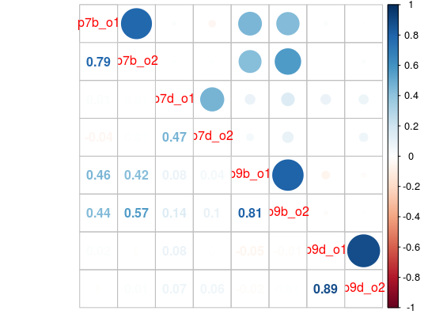

Gran diferencia con ELSOC, donde la correlación entreolas del salario percibido obrero es 0.019, mientras en la encuesta FONDECYT es de 0.47. En ambos casos los filtros de casos extremos aplicados son los mismos (<50000 y >1000000000 a missing).

Opción: eliminar más casos extremos ELSOC específicamente en relación a las diferencias en las variables de percepción obrero. Para ello, se genera una variable con la diferencia (absoluta) entre olas

```r
  elsocsalwk$difperob=
    abs(elsocsalwk$perob_2017-elsocsalwk$perob_2016)
  summary(elsocsalwk$difperob)
```

```
##     Min.  1st Qu.   Median     Mean  3rd Qu.     Max.     NA's
##        0    20000    50000   110609   100000 14700000      182
```

```r
  elsocsalwk %>%
    select(id,perob_2016,perob_2017,difperob) %>%
    filter(difperob>200000)
```

```
## # A tibble: 183 x 4
##         id perob_2016 perob_2017 difperob
##      <dbl>      <dbl>      <dbl>    <dbl>
##  1 1101022     250000     600000   350000
##  2 1101091     257000    3500000  3243000
##  3 1101151     300000     600000   300000
##  4 1107013     250000    2800009  2550009
##  5 2101032     600000     350000   250000
##  6 2101081     500000     275000   225000
##  7 2101182    2500000     300000  2200000
##  8 2101202     300000    2760000  2460000
##  9 2101223     200000     600000   400000
## 10 2101265     285000     600000   315000
## # ... with 173 more rows
```

Existen 183 casos donde la diferencia en la percepción del salario del obrero es mayor a 200.000. Ahora, con este filtro, ver si mejora la correlación:

```r
  elsocsalwkf = elsocsalwk %>% filter(difperob<200000)

  cormat_perob_f=cor(elsocsalwkf[2:9], use ="na.or.complete", method = "pearson")
    sjt.corr(elsocsalwkf[2:9], triangle = "lower",na.deletion = c("pairwise"))
```

|  | jusge_2016 | jusge_2017 | jusob_2016 | jusob_2017 | perge_2016 | perge_2017 | perob_2016 | perob_2017 |
| --- | --- | --- | --- | --- | --- | --- | --- | --- |
| jusge_2016 |  |  |  |  |  |  |  |  |
| jusge_2017 | 0.007 |  |  |  |  |  |  |  |
| jusob_2016 | 0.134*** | -0.003 |  |  |  |  |  |  |
| jusob_2017 | -0.024 | -0.022 | -0.004 |  |  |  |  |  |
| perge_2016 | 0.395*** | 0.006 | -0.001 | -0.037 |  |  |  |  |
| perge_2017 | 0.037 | 0.447*** | -0.003 | -0.036 | 0.064** |  |  |  |
| perob_2016 | -0.024 | -0.004 | 0.009 | 0.216*** | -0.032 | 0.004 |  |  |
| perob_2017 | -0.032 | 0.000 | -0.011 | 0.095*** | -0.033 | -0.001 | 0.417*** |  |
| Computed correlation used pearson-method with pairwise-deletion. |  |  |  |  |  |  |  |  |

```r
  cormat_perob_f
```

```
##             jusge_2016    jusge_2017    jusob_2016   jusob_2017
## jusge_2016  1.00000000  0.0132878399  0.1789881773 -0.025288178
## jusge_2017  0.01328784  1.0000000000 -0.0037428382 -0.022631351
## jusob_2016  0.17898818 -0.0037428382  1.0000000000 -0.004286474
## jusob_2017 -0.02528818 -0.0226313506 -0.0042864744  1.000000000
## perge_2016  0.40184648  0.0074081701 -0.0001855428 -0.035844152
## perge_2017  0.05207225  0.4485478601 -0.0016459928 -0.039200070
## perob_2016 -0.01209401 -0.0038290464  0.0077770888  0.205777257
## perob_2017 -0.01869840 -0.0003519165 -0.0103528135  0.091136428
##               perge_2016   perge_2017   perob_2016    perob_2017
## jusge_2016  0.4018464772  0.052072253 -0.012094007 -0.0186984032
## jusge_2017  0.0074081701  0.448547860 -0.003829046 -0.0003519165
## jusob_2016 -0.0001855428 -0.001645993  0.007777089 -0.0103528135
## jusob_2017 -0.0358441521 -0.039200070  0.205777257  0.0911364278
## perge_2016  1.0000000000  0.076658563 -0.035465618 -0.0349796177
## perge_2017  0.0766585634  1.000000000 -0.008758381  0.0045082198
## perob_2016 -0.0354656180 -0.008758381  1.000000000  0.4140940735
## perob_2017 -0.0349796177  0.004508220  0.414094073  1.0000000000
```

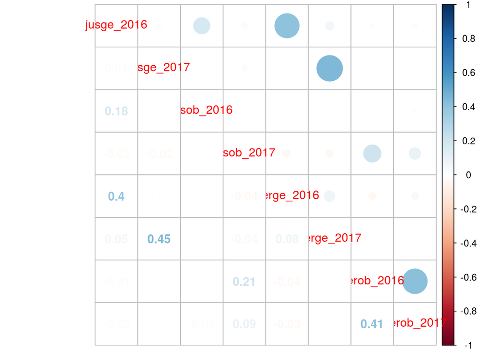

```r
  corrplot.mixed(cormat_perob_f)
```

```r
  elsocsalwk$difjusob=abs(elsocsalwk$jusob_2017-elsocsalwk$jusob_2016)

  summary(elsocsalwk$difjusob)
```

```
##      Min.   1st Qu.    Median      Mean   3rd Qu.      Max.      NA's
##         0     50000    100000   5106790    300000 479910000       165
```

```r
  elsocsalwk %>% select(id,jusob_2016,jusob_2017,difjusob) %>%  filter(difjusob>500000)
```

```
## # A tibble: 196 x 4
##         id jusob_2016 jusob_2017 difjusob
##      <dbl>      <dbl>      <dbl>    <dbl>
##  1 1101083     500000    7500000  7000000
##  2 1101091     500000    7000000  6500000
##  3 1101171     500000    7000000  6500000
##  4 2101033     200000    1000000   800000
##  5 2101093     580000    2000000  1420000
##  6 2101143    8000000     500000  7500000
##  7 2101191     200000     900000   700000
##  8 2101201    4000000     700000  3300000
##  9 2101241    1500000     800000   700000
## 10 3101033    2000000    5000000  3000000
## # ... with 186 more rows
```

Aquí hay 196 casos de alta inconsistencia … filtrando la matriz completa por esto:

```r
  elsocsalwkf2 = elsocsalwk %>% filter(difjusob<500000)
```

Y las correlaciones:

```r
    sjt.corr(elsocsalwkf2[2:9], triangle = "lower",na.deletion = c("pairwise"))
```

|  | jusge_2016 | jusge_2017 | jusob_2016 | jusob_2017 | perge_2016 | perge_2017 | perob_2016 | perob_2017 |
| --- | --- | --- | --- | --- | --- | --- | --- | --- |
| jusge_2016 |  |  |  |  |  |  |  |  |
| jusge_2017 | 0.013 |  |  |  |  |  |  |  |
| jusob_2016 | -0.073** | -0.006 |  |  |  |  |  |  |
| jusob_2017 | -0.004 | -0.032 | 0.499*** |  |  |  |  |  |
| perge_2016 | 0.345*** | 0.003 | 0.007 | 0.023 |  |  |  |  |
| perge_2017 | 0.029 | 0.433*** | -0.003 | -0.019 | 0.056* |  |  |  |
| perob_2016 | -0.014 | -0.002 | 0.084*** | 0.030 | 0.014 | 0.018 |  |  |
| perob_2017 | -0.011 | -0.002 | 0.057** | 0.100*** | 0.002 | 0.135*** | 0.014 |  |
| Computed correlation used pearson-method with pairwise-deletion. |  |  |  |  |  |  |  |  |

Con esto sube considerablemente a 0.5, aunque todavía lejos de la encuesta FONDECYT de referencia, que es casi el doble (0.88)

Ahora, cuantos casos se pierden al filtrar por ambos pares de correlación?

```r
elsocsalwk %>% select(difjusob,difperob) %>%  filter(difperob>200000 | difjusob>500000)
```

```
## # A tibble: 339 x 2
##    difjusob difperob
##       <dbl>    <dbl>
##  1        0   350000
##  2  7000000    50000
##  3  6500000  3243000
##  4   250000   300000
##  5  6500000    50000
##  6    50000  2550009
##  7   150000   250000
##  8   800000    65000
##  9    50000   225000
## 10  1420000    56000
## # ... with 329 more rows
```

Se pierden 339 casos … sumando los que se perdían anteriormente por separad (196 + 183= 379) nos muestra que la mayor parte de los casos inconsistentes no son comunes, sino que específicos a cada par de variables. Por lo tanto, requeriría una estrategia de ir eliminando casos por cada par de variables que se incluya, haciendo poco viables los análisis que vayan más allá de lo bivariado.

# Estatus subjetivo

Veamos ahora si lo que sucede con las variables de brechas se aplica también a otras variables, ya que a lo mejor es algo específico a la digitación de las respuestas de salarios.

- d1_01: estatus subjetivo (ssta) 0-10
- d1_02: ssta familia origen 0-10
- d1_03: ssta hijos 0-10

```r
  sstatw1=elsocw1 %>% select(id,d1_01,d1_02,d1_03)
  sstatw2=elsocw2 %>% select(idencuesta,d1_01,d1_02,d1_03)
```

Rename sustantivo y homologado para merge

```r
  sstatw1 <- rename(sstatw1,
                    sstat=d1_01,
                    fssta=d1_02,
                    hssta=d1_03)

  sstatw2 <- rename(sstatw2,
                    id=idencuesta,
                    sstat=d1_01,
                    fssta=d1_02,
                    hssta=d1_03)

  # add wave variable
  sstatw1$year=2016
  sstatw2$year=2017
  sstatw1$wave=1
  sstatw2$wave=1 # para luego filtrar por casos con ambas olas
  names(sstatw1)
```

```
## [1] "id"    "sstat" "fssta" "hssta" "year"  "wave"
```

```r
  names(sstatw2)
```

```
## [1] "id"    "sstat" "fssta" "hssta" "year"  "wave"
```

Append datasets long (para limpieza unificada)

```r
  elsocsstat=rbind(sstatw1,sstatw2)
  dim(elsocsstat)
```

```
## [1] 5505    6
```

```r
  elsocsstat %>% summarise_all(funs(sum(is.na(.))))
```

```
## # A tibble: 1 x 6
##      id sstat fssta hssta  year  wave
##   <int> <int> <int> <int> <int> <int>
## 1     0     0     0     0     0     0
```

```r
  summary(elsocsstat)
```

```
##        id                sstat            fssta            hssta
##  Min.   :  1101011   Min.   : 0.000   Min.   : 0.000   Min.   : 0.000
##  1st Qu.:  5402041   1st Qu.: 4.000   1st Qu.: 3.000   1st Qu.: 5.000
##  Median :  8108141   Median : 5.000   Median : 4.000   Median : 6.000
##  Mean   :  8924363   Mean   : 4.777   Mean   : 4.452   Mean   : 8.504
##  3rd Qu.: 13111016   3rd Qu.: 5.000   3rd Qu.: 5.000   3rd Qu.: 8.000
##  Max.   :131230214   Max.   :99.000   Max.   :99.000   Max.   :99.000
##       year           wave
##  Min.   :2016   Min.   :1
##  1st Qu.:2016   1st Qu.:1
##  Median :2016   Median :1
##  Mean   :2016   Mean   :1
##  3rd Qu.:2017   3rd Qu.:1
##  Max.   :2017   Max.   :1
```

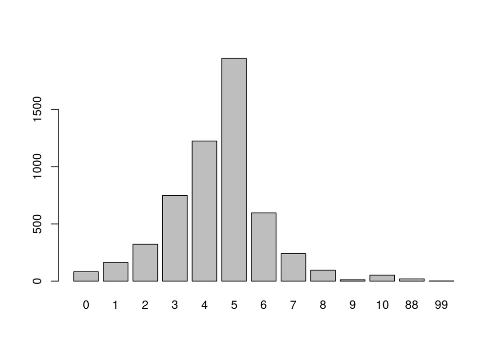

```
## Donde se ubicaria usted en la sociedad chilena?
##       Frequency   Percent
## 0            82   1.48955
## 1           163   2.96094
## 2           322   5.84923
## 3           749  13.60581
## 4          1224  22.23433
## 5          1946  35.34968
## 6           596  10.82652
## 7           240   4.35967
## 8            96   1.74387
## 9            12   0.21798
## 10           53   0.96276
## 88           20   0.36331
## 99            2   0.03633
## Total      5505 100.00000
```

```r
  freq(elsocsstat$sstat)
```

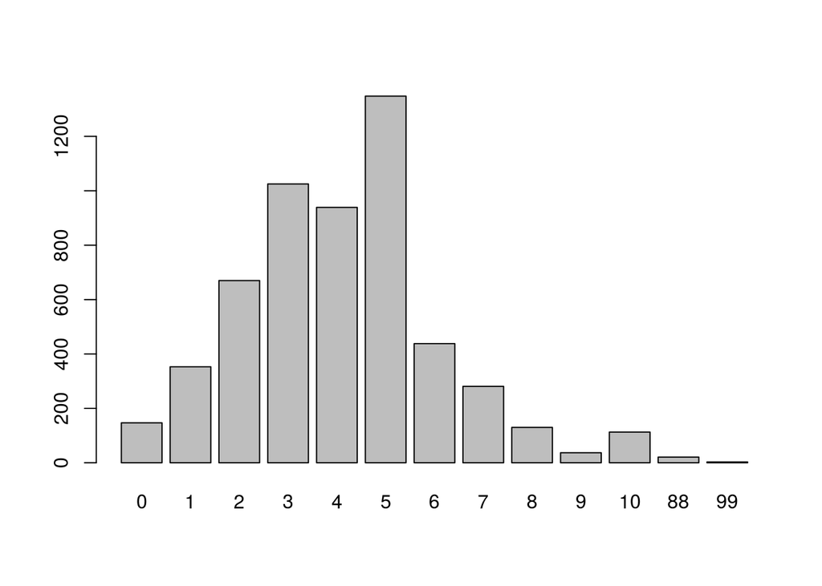

```
## Y pensando en la familia en la que usted crecio, donde se ubicarian ellos en est
##       Frequency  Percent
## 0           147   2.6703
## 1           353   6.4124
## 2           670  12.1708
## 3          1025  18.6194
## 4           939  17.0572
## 5          1348  24.4868
## 6           438   7.9564
## 7           281   5.1045
## 8           130   2.3615
## 9            37   0.6721
## 10          113   2.0527
## 88           21   0.3815
## 99            3   0.0545
## Total      5505 100.0000
```

```r
  freq(elsocsstat$fssta)
```

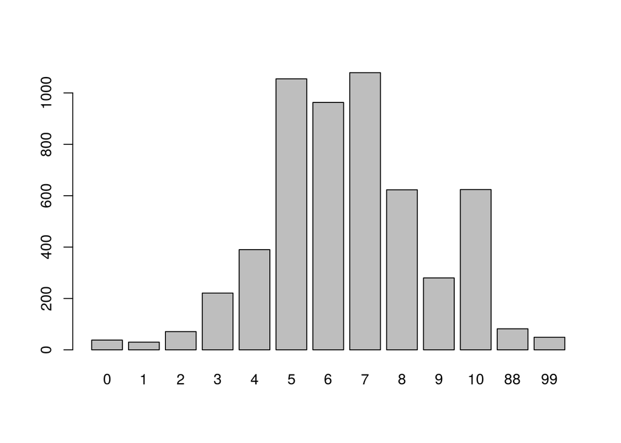

```
## Si usted tiene actualmente hijos o si los tuviera en el futuro, donde cree usted
##       Frequency  Percent
## 0            38   0.6903
## 1            30   0.5450
## 2            71   1.2897
## 3           221   4.0145
## 4           390   7.0845
## 5          1055  19.1644
## 6           963  17.4932
## 7          1079  19.6004
## 8           623  11.3170
## 9           280   5.0863
## 10          624  11.3351
## 88           82   1.4896
## 99           49   0.8901
## Total      5505 100.0000
```

```r
  freq(elsocsstat$hssta)
```

Missings

```r
elsocsstat[2:4][elsocsstat[2:4] > 10] <- NA #missing encuesta

summary(elsocsstat)
```

```
##        id                sstat           fssta           hssta
##  Min.   :  1101011   Min.   : 0.00   Min.   : 0.00   Min.   : 0.000
##  1st Qu.:  5402041   1st Qu.: 4.00   1st Qu.: 3.00   1st Qu.: 5.000
##  Median :  8108141   Median : 5.00   Median : 4.00   Median : 6.000
##  Mean   :  8924363   Mean   : 4.44   Mean   : 4.08   Mean   : 6.465
##  3rd Qu.: 13111016   3rd Qu.: 5.00   3rd Qu.: 5.00   3rd Qu.: 8.000
##  Max.   :131230214   Max.   :10.00   Max.   :10.00   Max.   :10.000
##                      NA's   :22      NA's   :24      NA's   :131
##       year           wave
##  Min.   :2016   Min.   :1
##  1st Qu.:2016   1st Qu.:1
##  Median :2016   Median :1
##  Mean   :2016   Mean   :1
##  3rd Qu.:2017   3rd Qu.:1
##  Max.   :2017   Max.   :1
##
```

```r
elsocsstat %>% group_by(year) %>%   summarise_all(funs(sum(is.na(.))))
```

```
## # A tibble: 2 x 6
##    year    id sstat fssta hssta  wave
##   <dbl> <int> <int> <int> <int> <int>
## 1  2016     0    12    10    74     0
## 2  2017     0    10    14    57     0
```

- Pasar a Wide

```r
    elsocsstatw= elsocsstat %>%
      gather(variable, value, -(c(id,year))) %>%
      unite(temp, variable, year) %>% # puede ser year primero y queda al principio de la variable
      spread(temp,value)
  names(elsocsstatw)
```

```
## [1] "id"         "fssta_2016" "fssta_2017" "hssta_2016" "hssta_2017"
## [6] "sstat_2016" "sstat_2017" "wave_2016"  "wave_2017"
```

```r
  dim(elsocsstatw)
```

```
## [1] 2985    9
```

```r
  elsocsstatw %>% summarise_all(funs(sum(!is.na(.))))
```

```
## # A tibble: 1 x 9
##      id fssta_2016 fssta_2017 hssta_2016 hssta_2017 sstat_2016 sstat_2017
##   <int>      <int>      <int>      <int>      <int>      <int>      <int>
## 1  2985       2974       2507       2910       2464       2972       2511
## # ... with 2 more variables: wave_2016 <int>, wave_2017 <int>
```

```r
    names(elsocsstatw)
```

```
## [1] "id"         "fssta_2016" "fssta_2017" "hssta_2016" "hssta_2017"
## [6] "sstat_2016" "sstat_2017" "wave_2016"  "wave_2017"
```

```r
    summary(elsocsstatw)
```

```
##        id              fssta_2016       fssta_2017       hssta_2016
##  Min.   :  1101011   Min.   : 0.000   Min.   : 0.000   Min.   : 0.000
##  1st Qu.:  5402052   1st Qu.: 3.000   1st Qu.: 3.000   1st Qu.: 5.000
##  Median :  8108141   Median : 4.000   Median : 4.000   Median : 6.000
##  Mean   :  8910432   Mean   : 3.963   Mean   : 4.219   Mean   : 6.287
##  3rd Qu.: 13111013   3rd Qu.: 5.000   3rd Qu.: 5.000   3rd Qu.: 8.000
##  Max.   :131230214   Max.   :10.000   Max.   :10.000   Max.   :10.000
##                      NA's   :11       NA's   :478      NA's   :75
##    hssta_2017       sstat_2016      sstat_2017       wave_2016
##  Min.   : 0.000   Min.   : 0.00   Min.   : 0.000   Min.   :1
##  1st Qu.: 5.000   1st Qu.: 3.00   1st Qu.: 4.000   1st Qu.:1
##  Median : 7.000   Median : 5.00   Median : 5.000   Median :1
##  Mean   : 6.676   Mean   : 4.34   Mean   : 4.558   Mean   :1
##  3rd Qu.: 8.000   3rd Qu.: 5.00   3rd Qu.: 5.000   3rd Qu.:1
##  Max.   :10.000   Max.   :10.00   Max.   :10.000   Max.   :1
##  NA's   :521      NA's   :13      NA's   :474      NA's   :1
##    wave_2017
##  Min.   :1
##  1st Qu.:1
##  Median :1
##  Mean   :1
##  3rd Qu.:1
##  Max.   :1
##  NA's   :464
```

- Datos casos ambas olas (w=waves)

```r
dim(elsocsstatw)
```

```
## [1] 2985    9
```

```r
elsocsstatwk = elsocsstatw %>% filter(wave_2017==1)
dim(elsocsstatwk)
```

```
## [1] 2521    9
```

```r
elsocsstat %>% group_by(year) %>% select(Año=year,"Personal"=sstat,"Familiar"=fssta,"Hijos"= hssta) %>%   summarise_all(funs(mean(., na.rm = TRUE)))
```

```
## # A tibble: 2 x 4
##     Año Personal Familiar    Hijos
##   <dbl>    <dbl>    <dbl>    <dbl>
## 1  2016 4.339502 3.962677 6.286598
## 2  2017 4.557945 4.218987 6.676542
```

- Correlaciones (sin sstatus hijos para comparar con FONDECYT)

```r
sjt.corr(elsocsstatwk[,c("sstat_2016","fssta_2016","sstat_2017","fssta_2017")], triangle = "lower",na.deletion = c("pairwise"))
```

|  | sstat_2016 | fssta_2016 | sstat_2017 | fssta_2017 |
| --- | --- | --- | --- | --- |
| sstat_2016 |  |  |  |  |
| fssta_2016 | 0.568*** |  |  |  |
| sstat_2017 | 0.329*** | 0.213*** |  |  |
| fssta_2017 | 0.236*** | 0.335*** | 0.532*** |  |
| Computed correlation used pearson-method with pairwise-deletion. |  |  |  |  |

Contraste con Fondecyt:

```r
 load("fond_sstat.rda")


sjt.corr(fond_sstat, triangle = "lower",na.deletion = c("pairwise"),var.labels = c("sstat_o1","fssta_o1","sstat_o2","fssta_o2"))
```

|  | sstat_o1 | fssta_o1 | sstat_o2 | fssta_o2 |
| --- | --- | --- | --- | --- |
| sstat_o1 |  |  |  |  |
| fssta_o1 | 0.608*** |  |  |  |
| sstat_o2 | 0.843*** | 0.528*** |  |  |
| fssta_o2 | 0.566*** | 0.802*** | 0.647*** |  |
| Computed correlation used pearson-method with pairwise-deletion. |  |  |  |  |

Nuevamente tenemos que las correlaciones con la encuesta de referencia (FONDECYT) son más del doble que ELSOC cuando se comparan las correlaciones ENTRE OLAS. Cuando se comparan dentro de una misma ola igual son menores, pero el contraste no es tan grande.

Propuestas:

- revisar nuevamente ELSOC y asegurarse que las correlaciones/merge estén bien
- considerar otra encuesta externa de referencia, de preferencia internacinoal con variables similares y también con otras variables (ej: confianza en instituciones)
- revisar con Microdatos temas de folios, supervisión, etc.